# QTM 150: Babynames in-class exercise

```r
str(babynames)
```

```
## tibble [1,924,665 × 5] (S3: tbl_df/tbl/data.frame)
##  $ year: num [1:1924665] 1880 1880 1880 1880 1880 1880 1880 1880 1880 1880 ...
##  $ sex : chr [1:1924665] "F" "F" "F" "F" ...
##  $ name: chr [1:1924665] "Mary" "Anna" "Emma" "Elizabeth" ...
##  $ n   : int [1:1924665] 7065 2604 2003 1939 1746 1578 1472 1414 1320 1288 ...
##  $ prop: num [1:1924665] 0.0724 0.0267 0.0205 0.0199 0.0179 ...
```

```r
head(babynames)
```

```
## # A tibble: 6 × 5
##    year sex   name          n   prop
##   <dbl> <chr> <chr>     <int>  <dbl>
## 1  1880 F     Mary       7065 0.0724
## 2  1880 F     Anna       2604 0.0267
## 3  1880 F     Emma       2003 0.0205
## 4  1880 F     Elizabeth  1939 0.0199
## 5  1880 F     Minnie     1746 0.0179
## 6  1880 F     Margaret   1578 0.0162
```

Q1. Babynames dataset includes ~2 million observations (NOT ~2 million names) from year 1880 to 2017. How many unique names were used in each year, and which year had the most number of unique names recorded in this dataset? Also, for the year with the most number of unique names used, how mamy of those names were used for females?

```r
table(babynames$year)
```

```
##
##  1880  1881  1882  1883  1884  1885  1886  1887  1888  1889  1890  1891  1892
##  2000  1935  2127  2084  2297  2294  2392  2373  2651  2590  2695  2660  2921
##  1893  1894  1895  1896  1897  1898  1899  1900  1901  1902  1903  1904  1905
##  2831  2941  3049  3091  3028  3264  3042  3730  3153  3362  3389  3560  3655
##  1906  1907  1908  1909  1910  1911  1912  1913  1914  1915  1916  1917  1918
##  3633  3948  4018  4227  4629  4867  6351  6968  7965  9357  9696  9914 10399
##  1919  1920  1921  1922  1923  1924  1925  1926  1927  1928  1929  1930  1931
## 10369 10755 10857 10756 10643 10869 10638 10458 10406 10160  9818  9789  9297
##  1932  1933  1934  1935  1936  1937  1938  1939  1940  1941  1942  1943  1944
##  9384  9012  9180  9037  8893  8946  9030  8919  8961  9085  9425  9408  9154
##  1945  1946  1947  1948  1949  1950  1951  1952  1953  1954  1955  1956  1957
##  9024  9705 10371 10239 10268 10302 10462 10648 10838 10968 11113 11335 11564
##  1958  1959  1960  1961  1962  1963  1964  1965  1966  1967  1968  1969  1970
## 11521 11769 11921 12181 12206 12282 12396 11953 12152 12399 12935 13748 14780
##  1971  1972  1973  1974  1975  1976  1977  1978  1979  1980  1981  1982  1983
## 15293 15411 15681 16244 16944 17391 18175 18229 19038 19445 19472 19691 19403
##  1984  1985  1986  1987  1988  1989  1990  1991  1992  1993  1994  1995  1996
## 19503 20081 20649 21403 22364 23773 24719 25105 25427 25966 25995 26080 26423
##  1997  1998  1999  2000  2001  2002  2003  2004  2005  2006  2007  2008  2009
## 26971 27899 28550 29769 30269 30563 31183 32046 32546 34082 34950 35070 34702
##  2010  2011  2012  2013  2014  2015  2016  2017
## 34067 33903 33732 33269 33228 33098 32979 32469
```

```r
babynames %>%
  group_by(year) %>%
  summarize(no_unique = length(name)) %>%
  arrange(desc(no_unique))
```

```
## # A tibble: 138 × 2
##     year no_unique
##    <dbl>     <int>
##  1  2008     35070
##  2  2007     34950
##  3  2009     34702
##  4  2006     34082
##  5  2010     34067
##  6  2011     33903
##  7  2012     33732
##  8  2013     33269
##  9  2014     33228
## 10  2015     33098
## # … with 128 more rows
```

Q2. This dataset can also be used to examine the number of childbirths taken place each year by using variable n which describes how many times each name was used in each year. Use a time series plot (a line plot) visualizing the yearly number of childbirths. Use different colors for males and females.

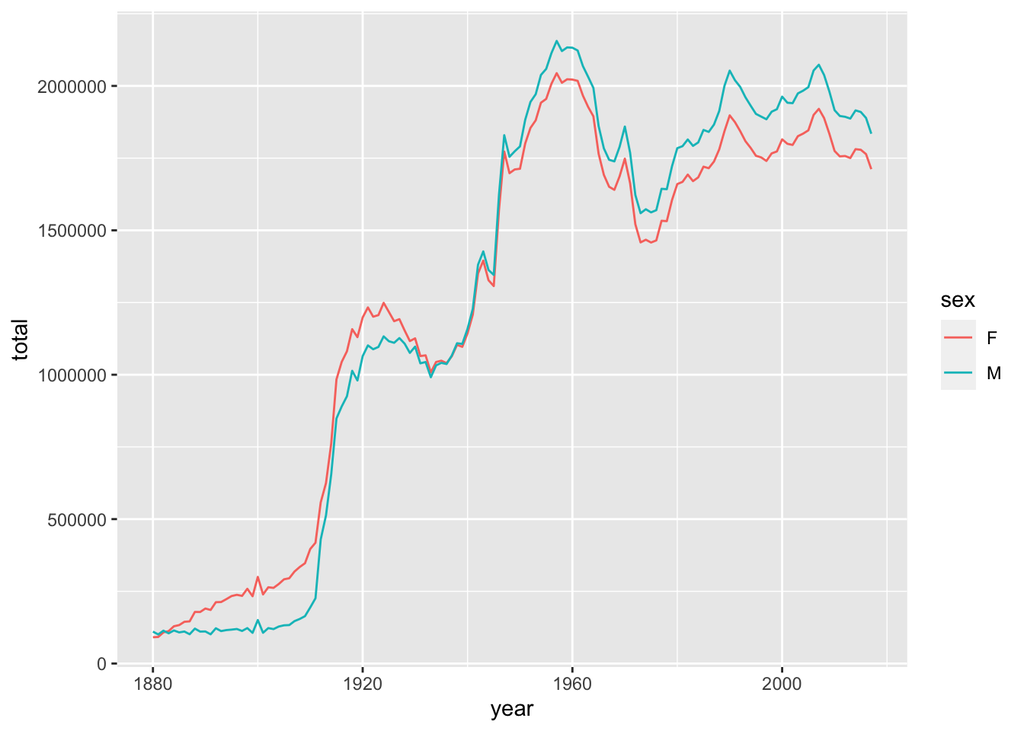

```r
babynames %>%
  group_by(year, sex) %>%
  summarize(total = sum(n)) %>%
  ggplot(aes(year, total, color = sex)) +
  geom_line()
```

Q3. Back to the babynames. For each year, what are the most popular male and female names? Do this only for the first 10 years (i.e., 1880~1889) and the last 10 years included in the dataset (i.e., 2008~2017). Do you see an interesting pattern?

```r
babynames %>%
  filter(year<=1890&&year>=1880) %>%
  group_by(name, sex) %>%
  summarize(num = sum(n, na.rm = T)) %>%
  arrange(desc(num))
```

```
## # A tibble: 107,973 × 3
## # Groups:   name [97,310]
##    name    sex       num
##    <chr>   <chr>   <int>
##  1 James   M     5150472
##  2 John    M     5115466
##  3 Robert  M     4814815
##  4 Michael M     4350824
##  5 Mary    F     4123200
##  6 William M     4102604
##  7 David   M     3611329
##  8 Joseph  M     2603445
##  9 Richard M     2563082
## 10 Charles M     2386048
## # … with 107,963 more rows
```

Q4. (A) What are the all-time top 10 names used to name babies? Also, (B) what are the all-time top 5 names used to name boys and the all-time top 5 names used to name girls? Describe how (A) and (B) are different.

```r
babynames %>%
  group_by(name) %>%
  summarize(num = sum(n, na.rm = T)) %>%
  arrange(desc(num)) %>%
  slice_max(num, n = 10)
```

```
## # A tibble: 10 × 2
##    name        num
##    <chr>     <int>
##  1 James   5173828
##  2 John    5137142
##  3 Robert  4834915
##  4 Michael 4372536
##  5 Mary    4138360
##  6 William 4118553
##  7 David   3624225
##  8 Joseph  2614083
##  9 Richard 2572613
## 10 Charles 2398453
```

```r
babynames %>%
  filter(sex %in% "M") %>%
  group_by(name) %>%
  summarize(num = sum(n, na.rm = T)) %>%
  arrange(desc(num)) %>%
  slice_max(num, n = 5)
```

```
## # A tibble: 5 × 2
##   name        num
##   <chr>     <int>
## 1 James   5150472
## 2 John    5115466
## 3 Robert  4814815
## 4 Michael 4350824
## 5 William 4102604
```

```r
babynames %>%
  filter(sex %in% "F") %>%
  group_by(name) %>%
  summarize(num = sum(n, na.rm = T)) %>%
  arrange(desc(num)) %>%
  slice_max(num, n = 5)
```

```
## # A tibble: 5 × 2
##   name          num
##   <chr>       <int>
## 1 Mary      4123200
## 2 Elizabeth 1629679
## 3 Patricia  1571692
## 4 Jennifer  1466281
## 5 Linda     1452249
```

Q5. What are the top 5 most popular names in the year you were born?

```r
top5names2002 <- babynames %>%
  filter(year == 2002) %>%
  group_by(name) %>%
  summarize(num = sum(n, na.rm = T)) %>%
  arrange(desc(num)) %>%
  top_n(5) %>%
  select(name)
top5names2002
```

```
## # A tibble: 5 × 1
##   name
##   <chr>
## 1 Jacob
## 2 Michael
## 3 Joshua
## 4 Matthew
## 5 Emily
```

Q6: Using the 5 names from Q5, visualize a trend showing the changes in the frequency of each name over the years.

```r
class(top5names2002)
```

```
## [1] "tbl_df"     "tbl"        "data.frame"
```

```r
class(as.vector(top5names2002))
```

```
## [1] "list"
```

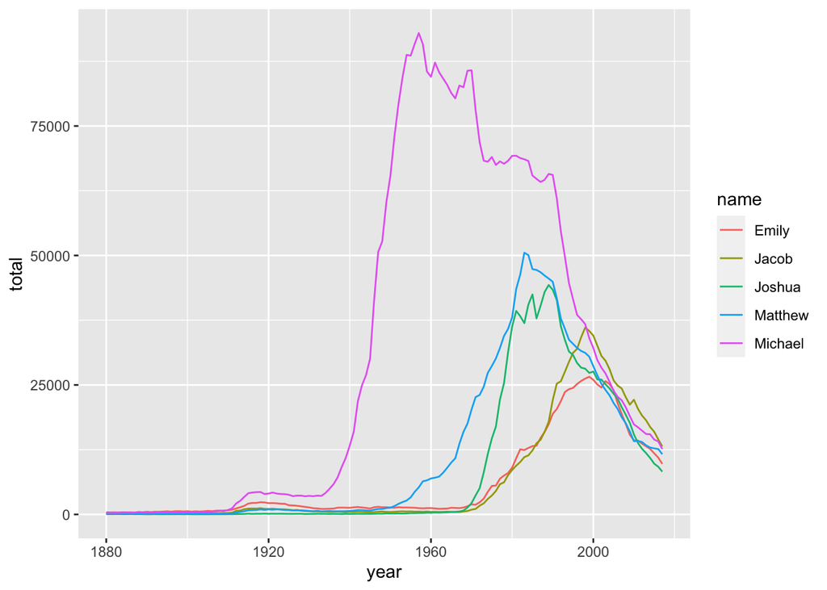

```r
babynames %>%
  filter(name %in% as.vector(top5names2002)[[1]]) %>%
  group_by(year, name) %>%
  summarize(total = sum(n)) %>%
  ggplot(aes(year, total, color=name)) + geom_line()
```